# Visualizing Genomics Data

Rockefeller University, Bioinformatics Resource Centre

http://rockefelleruniversity.github.io/RU_VisualizingGenomicsData/

## The Course

- The Course.
- Visualising high-throughput data.
- Dimension reduction.
- PCA and loadings.
- Clustering.
- Grouping by kmeans.
- Testing gene clusters.

## Reminder of data types in Bioconductor

We will also encounter and make use of many data structures and data types which we have seen throughout our courses on HTS data. You can revisit this material to refresh on HTS data analysis in Bioconductor and R below.

- [Bioconductor](https://rockefelleruniversity.github.io/Bioconductor_Introduction/).
- [Genomic Intervals](https://rockefelleruniversity.github.io/Bioconductor_Introduction/r_course/presentations/slides/GenomicIntervals_In_Bioconductor.html)
- [Genomic Scores](https://rockefelleruniversity.github.io/Bioconductor_Introduction/r_course/presentations/slides/GenomicScores_In_Bioconductor.html)
- [Sequences](https://rockefelleruniversity.github.io/Bioconductor_Introduction/r_course/presentations/slides/SequencesInBioconductor.html)
- [Gene Models](https://rockefelleruniversity.github.io/Bioconductor_Introduction/r_course/presentations/slides/GenomicFeatures_In_Bioconductor.html)
- [Alignments](https://rockefelleruniversity.github.io/Bioconductor_Introduction/r_course/presentations/slides/AlignedDataInBioconductor.html).
- [ChIP-seq](http://rockefelleruniversity.github.io/RU_ChIPseq/).
- [ATAC-seq](http://rockefelleruniversity.github.io/RU_ATACseq/).
- [RNA-seq](http://rockefelleruniversity.github.io/RU_RNAseq/).

## Materials. - Presentations, source code and practicals.

Once the zip file in unarchived. All presentations as HTML slides and pages, their R code and HTML practical sheets will be available in the directories underneath.

- **viz_course/presentations/Slides/** Presentations as an HTML slide show.
- **viz_course/presentations/exercises/** Some tasks/examples to work through.

## Set the Working directory

Before running any of the code in the practicals or slides we need to set the working directory to the folder we unarchived.

You may navigate to the unarchived VisualisingGenomicsData folder in the Rstudio menu

**Session -> Set Working Directory -> Choose Directory**

or in the console.

```r
setwd("/PathToMyDownload/VisualizingGenomicsData/viz_course/presentations/Slides")
# e.g. setwd("~/Downloads/VisualizingGenomicsData/viz_course/presentations/Slides")
```

## Vizualising high dimensional Biological data.

With many high throughput sequencing experiments we are able to gain a genome wide view of our assays (in RNA-seq we measure every gene’s expression, in ChIP-seq we identify all events for a user-defined transcription factor/mark, in ATAC-seq we evaluate all open/accessible regions in the genome.)

[figure not shown]

## Vizualising high dimensional Biological data.

In todays session we will work with some of the RNA-seq data of adult mouse tissues from Bing Ren’s lab, Liver and Heart. - More information on liver data [can be found here](https://www.encodeproject.org/experiments/ENCSR000CHB/) - More information on heart data [can be found here](https://www.encodeproject.org/experiments/ENCSR000CGZ/) - More information on Kidney data [can be found here](https://www.encodeproject.org/experiments/ENCSR000CGZ/)

This represent a more complex experimental design than the two group comparison performed between activated and naive t-cells and so we will use some clustering and dimensional reduction tecniques to interrogate this data.

## Counts from SummariseOverlaps

With this BamFileList we can summarise from BAMs to produce our **RangedSummarizedExperiment** object of counts in genes across all samples.

We add in some metadata information for use with DESeq2 to our object with the **colData()** function.

```r
library(TxDb.Mmusculus.UCSC.mm10.knownGene)
library(GenomicAlignments)
geneExons <- exonsBy(TxDb.Mmusculus.UCSC.mm10.knownGene,by="gene")
geneCounts <- summarizeOverlaps(geneExons,myBams,
                                    ignore.strand = TRUE)
colData(geneCounts)$tissue <- c("Heart", "Heart","Kidney","Kidney","Liver","Liver")
```

## DESeq2

Further to our pair-wise comparisons we can extract an anova-like statistic identifying genes changing expression between conditions using the *LRT* test with our reduced model (no groups model).

```r
dds2 <- DESeq(dds,test="LRT",reduced = ~1)
AllChanges <- results(dds2)
```

## Visualing RNAseq data.

We can extract our normalised and transformed counts from the **DESeqTransform** object using the **assay()** function.

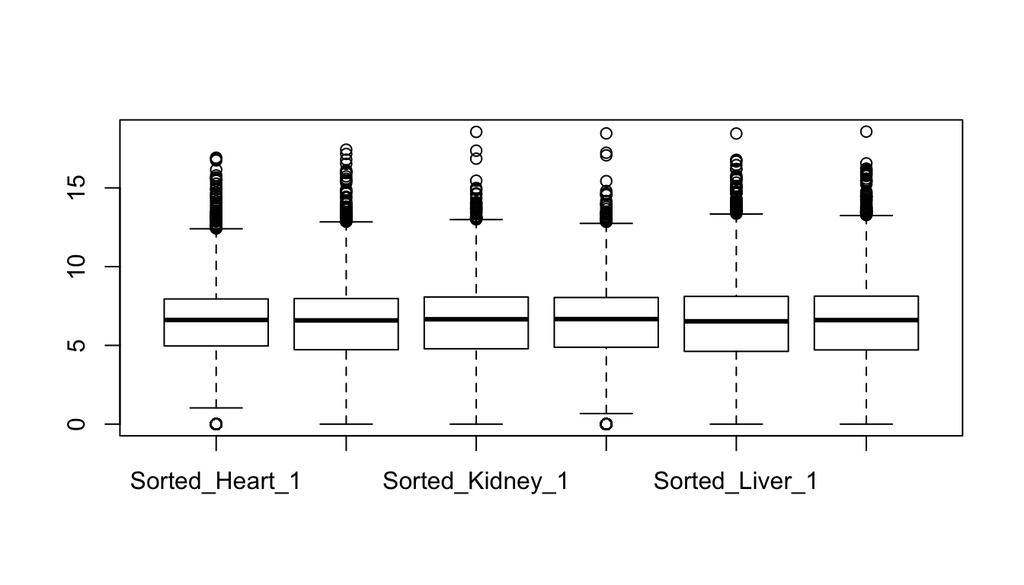

```r
matrixOfNorm <- assay(normLog2Counts)
boxplot(matrixOfNorm)
```

## Visualing RNAseq data.

We can apply an **rlog** transformation to our data using the **rlog()** function which will attempt to shrink the variance for genes based on their mean expression.

```r
rlogTissue <- rlog(dds)
rlogTissue
```

```
## class: DESeqTransform
## dim: 14454 6
## metadata(1): version
## assays(1): ''
## rownames(14454): 20671 27395 ... 26900 170942
## rowData names(26): baseMean baseVar ... dispFit rlogIntercept
## colnames(6): Sorted_Heart_1 Sorted_Heart_2 ... Sorted_Liver_1
##   Sorted_Liver_2
## colData names(2): Tissue sizeFactor
```

## Dimension reduction.

Since we have often have measured 1000s of genes over multiple genes we will often try and simplify this too a few dimensions or meta/eigen genes which represent major patterns of signal across samples found.

We hope the strongest patterns or sources of variation in our data are correlated with sample groups and so dimention reduction offers a methods to method to visually identify reproducibity of samples.

Common methods of dimention reduction include Principal Component Analysis, MultiFactorial Scaling and Non-negative Matrix Factorization.

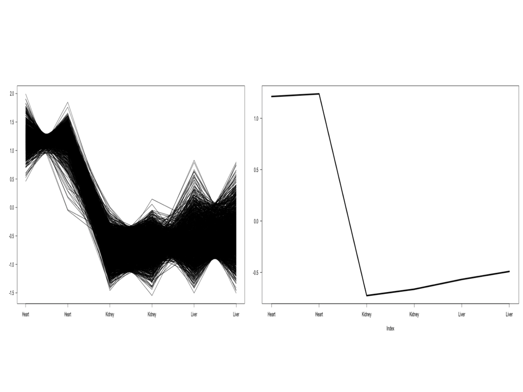

## PCA

This PCA show the separation of samples by their group and the localisation of samples with groups.

Since PC1 here explains 51% of total variances amongst samples and PC2 explains 44%, the reduction of dimensions can be seen to explain much of the changes among samples in 2 dimenstions.

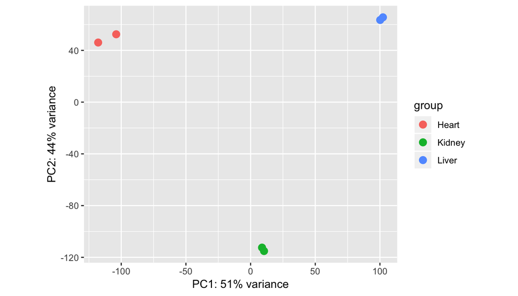

## PCA

We can now reproduce the previous plot from DEseq2 in basic graphics from this.

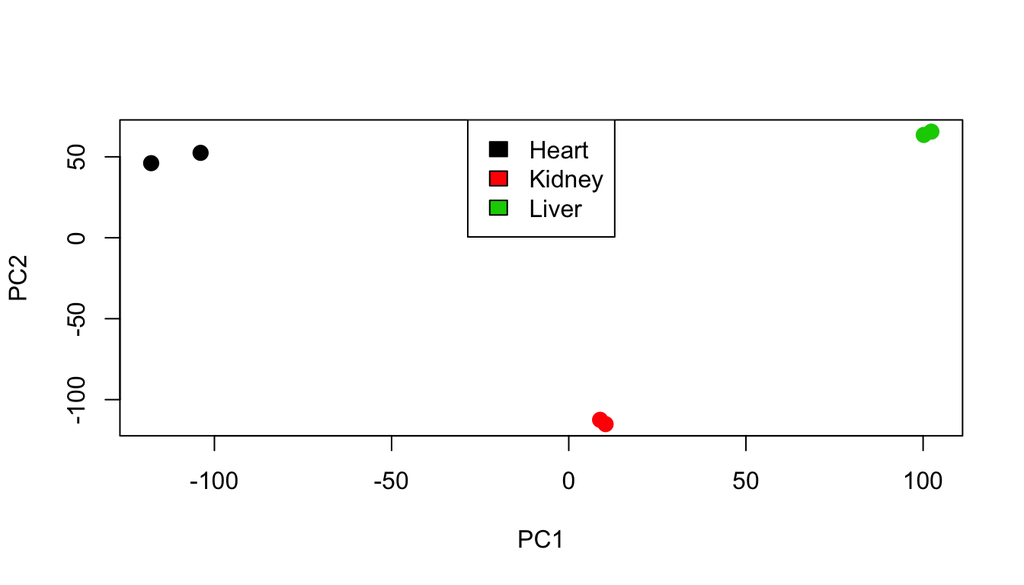

```r
plot(pcRes$x,
     col=colData(rlogTissue)$Tissue,
     pch=20,
     cex=2)
legend("top",legend = c("Heart","Kidney","Liver"),
       fill=unique(colData(rlogTissue)$Tissue))
```

## PCA

To investigate the seperation of Kidney samples along the negative axis of PC2 i can then look at which genes most negatively contribute to PC2.

Here we order by the most negative values for PC2 and select the top 100

```r
PC2markers <- sort(pcRes$rotation[,2],decreasing = FALSE)[1:100]
PC2markers[1:10]
```

```
##       20505       22242       56727       16483       77337       57394
## -0.06497094 -0.06001534 -0.05896033 -0.05895811 -0.05595482 -0.05505062
##       18399       20495       22598       20730
## -0.05307390 -0.05256083 -0.05205554 -0.05175358
```

## PCA

From the boxplot it is clear to see that the top100 genes are all specifically upregulated in Kidney tissue.

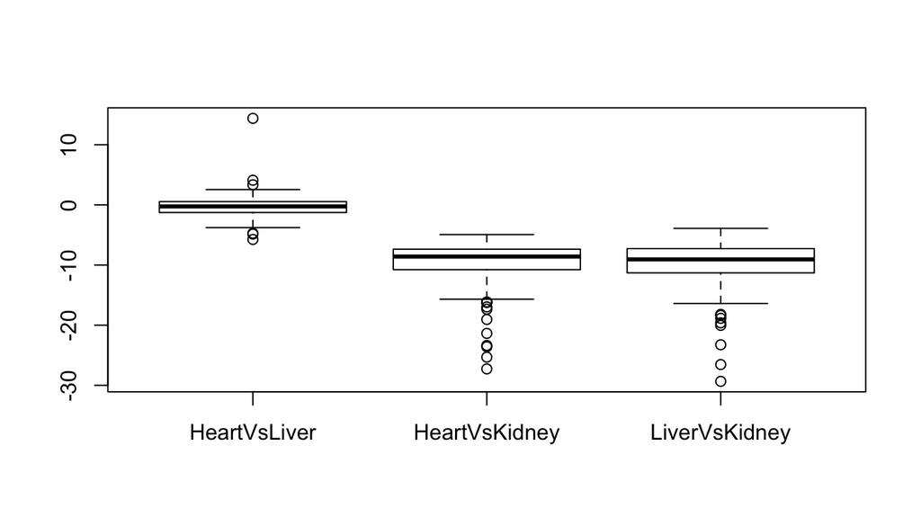

```r
boxplot(PC2_hVsl,PC2_hVsk,PC2_LVsk,
        names=c("HeartVsLiver","HeartVsKidney","LiverVsKidney"))
```

## Sample-to-Sample correlation

We can visualise the the correlation matrix using a heatmap following sample clustering.

First we need to convert our correlation matrix into a distance measure to be use in clustering by subtracting from 1 to give dissimilarity measure and converting with the **as.dist()** to a **dist** object.

We then create a matrix of distance values to plot in the heatmap from this using **as.matrix()** function.

```r
library(pheatmap)
sampleDists <- as.dist(1-cor(rlogMatrix))
sampleDistMatrix <- as.matrix(sampleDists)
```

## Sample-to-Sample correlation

We can use the **brewer.pal** and **colorRampPalette()** function to create a white to blue scale [as we have with **ggplot** scales](https://rockefelleruniversity.github.io/Plotting_In_R/r_course/presentations/slides/ggplot2.html#60).

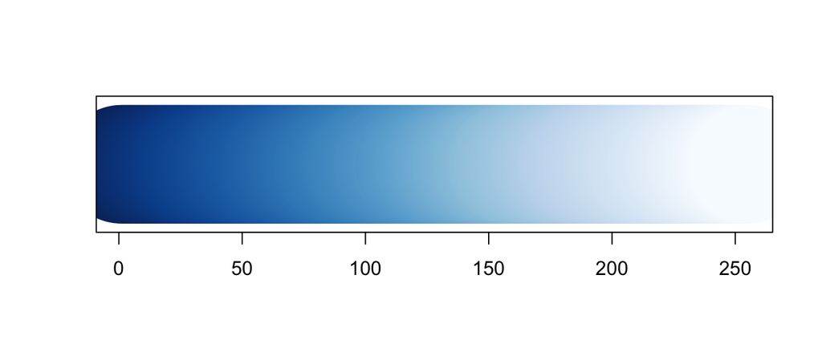

```r
library(RColorBrewer)
blueColours <- brewer.pal(9, "Blues")
colors <- colorRampPalette(rev(blueColours))(255)
plot(1:255,rep(1,255),
     col=colors,pch=20,cex=20,ann=FALSE,
     yaxt="n")
```

## Sample-to-Sample correlation

Finally we can add some column annotation to highlight group membership. We must provide annotation as a data.frame of metadata we wish to include with rownames matching column names.

Fortunetely that is exactly as we have set up from DEseq2. We can extract metadata from the DESeq2 object with **colData()** function and provide to the **annotation_col** parameter.

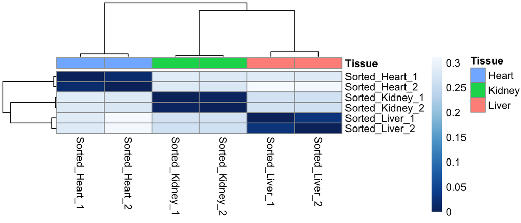

```r
annoCol <- as.data.frame(colData(dds))
pheatmap(sampleDistMatrix,
         clustering_distance_rows=sampleDists,
         clustering_distance_cols=sampleDists,
         color = colors,annotation_col = annoCo)
```

## Clustering genes and samples

We can pass our filtered matrix of expression to the **pheatmap()** function and set the **scale** parameter to *row* to allow for clustering of relative changes in gene expression.

Additionally due to the large number of genes, we turn rowname off with the **show_rownames** function.

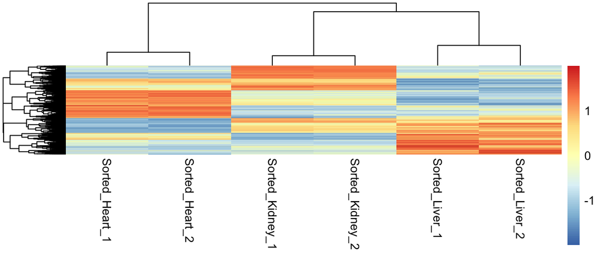

```r
library(pheatmap)
pheatmap(sigMat,
         scale="row",
         show_rownames = FALSE)
```

## Clustering genes and samples

Now we have a visual representation of changes in gene expression across samples we can use the clustering to derive groups of genes with similar expression patterns. Gene with similar expression profiles may share functional roles and so we can use these groups to further evaluate our gene expression data.

Many approaches to identifying clustered groups of genes exist including K-means, SOM and HOPACH.

K-means is implemented with the pheatmap package and so we can simply provide a desired number of clusters to the **kmeans_k** parameter.

```r
library(pheatmap)
set.seed(153)
k <-   pheatmap(sigMat,
           scale="row",kmeans_k = 7)
```

## Clustering genes and samples

The **pheatmap()** function returns information on clustering is return as a list and following k-means clustering the assignment of genes to clusters can be extracted from this.

```r
names(k$kmeans)
```

```
## [1] "cluster"      "centers"      "totss"        "withinss"
## [5] "tot.withinss" "betweenss"    "size"         "iter"
## [9] "ifault"
```

```r
clusterDF <- as.data.frame(factor(k$kmeans$cluster))
colnames(clusterDF) <- "Cluster"
clusterDF[1:10,,drop=FALSE]
```

```
##           Cluster
## 20671           1
## 27395           1
## 18777           5
## 21399           6
## 108664          2
## 319263          6
## 76187           5
## 70675           6
## 73824           6
## 100039596       2
```

## Clustering genes and samples

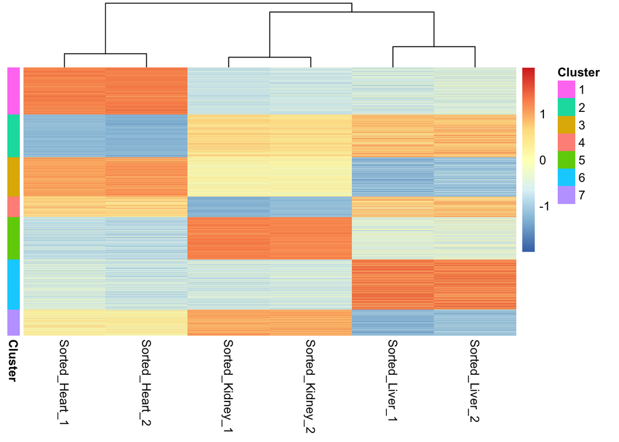

```r
OrderByCluster <- sigMat[order(clusterDF$Cluster),]

pheatmap(OrderByCluster,
           scale="row",annotation_row = clusterDF,
           show_rownames = FALSE,cluster_rows = FALSE)
```

## Testing gene clusters

Now we have some genes clusters from our expression data, we will want to invesitigate these clusters for any enrichment of fucntional terms within them.

Here we extract all genes in cluster 1, which appear to be our heart specific genes,

```r
heartSpecific <- rownames(clusterDF[clusterDF$Cluster == 1,,drop=FALSE])
heartSpecific[1:10]
```

```
##  [1] "20671"  "27395"  "109294" "240726" "14048"  "17681"  "57339"
##  [8] "74229"  "214855" "78321"
```

## Testing gene clusters

```r
library(goseq)
toTest <- nullp(heartSpecific,"mm10",id = "knownGene")
```

[figure not shown]

## PCA

Finally we can use our heatmaps to get a better idea of the pattern of expression associated with PC1 plot we saw earlier.

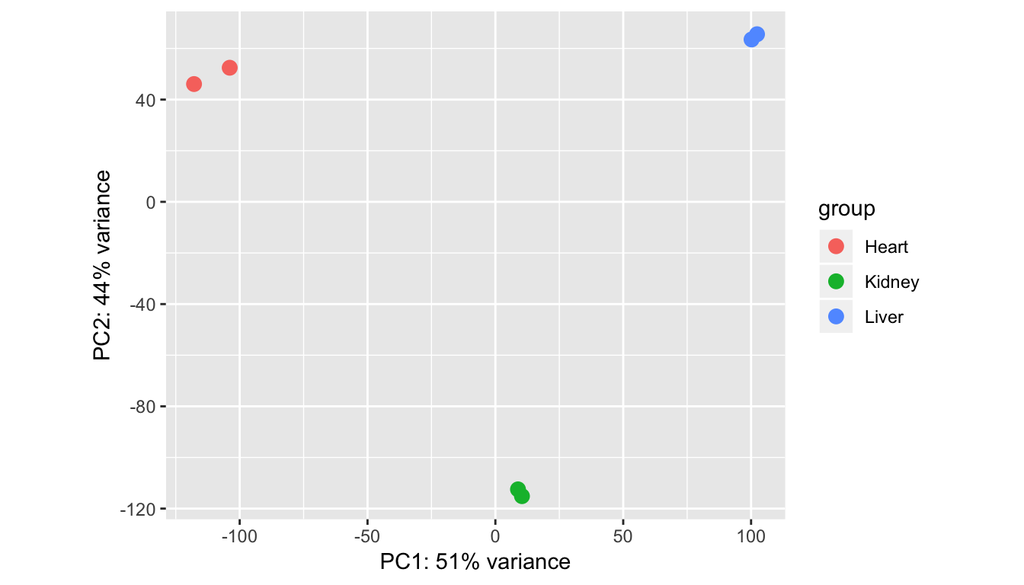

```r
plotPCA(rlogTissue,
        intgroup="Tissue",
        ntop=nrow(rlogTissue))
```

## PCA

Now we plot our heatmap of gene expression ordered by PC1 influence to reveal the PC1’s epression profile.

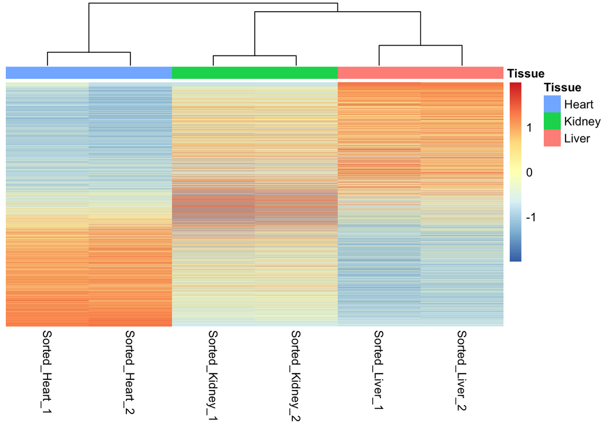

```r
pheatmap(PC1_mat,
         scale="row",
         cluster_rows=FALSE,
         show_rownames = FALSE,annotation_col = annoCol
         )
```

## Solutions

Time for solutions! Link here